# Spiny lobster abundance & community size structure along the Santa Barbara coast (2012-2018)

Analysis & Report by Jon Hart & Wes Newbury

11/15/2019

### **Introduction**

Spiny lobsters grow in great quantities off the coast of Santa Barbara and make delicious seafood. These lobsters are harvested in a number of ways throughout the year and it is thus important to understand the way their population fluctuates as well as what factors inform these changes.

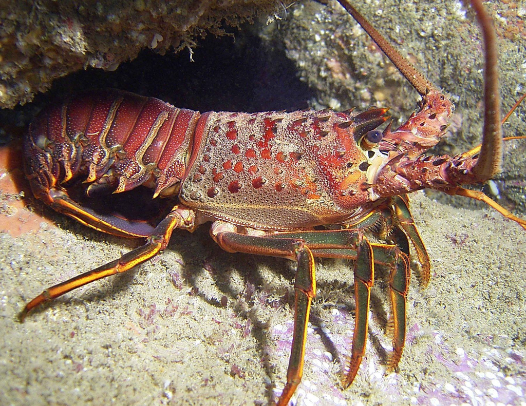

**Figure 1.** *California Spiny Lobster (Credit: [Catalina Island Marine Institute](https://cimioutdoored.org/ca-spiny-lobster/))*

By comparing lobster abundance, density, and size over five sites in Santa Barbara county we explore whether sites within Marine Protected Areas have significant differences in lobster populations over a six year period when compared to sites with no such protection.

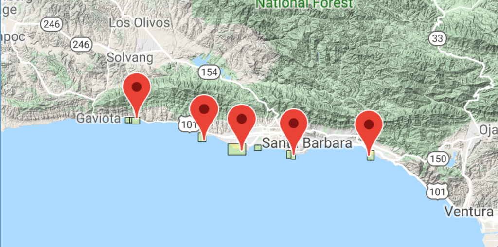

**Figure 2.** *The five sampling locations {left to right - Arroyo Quemado, Naples, Isla Vista, Mohawk, Carpenteria} Credit: SBC LTER- ([EDI Data Portal](https://portal.edirepository.org/nis/mapbrowse?scope=knb-lter-sbc&identifier=77&revision=newest))*

### **Results**

#### 1. Changes in lobster abundance over time and space

First, lets look at how sample lobster counts changed annually between 2012 & 2018 so we can start to see any trends on how geographic location, year, and whether sites are within a Marine Protected Area (MPA) might have an effect on lobster abundace.

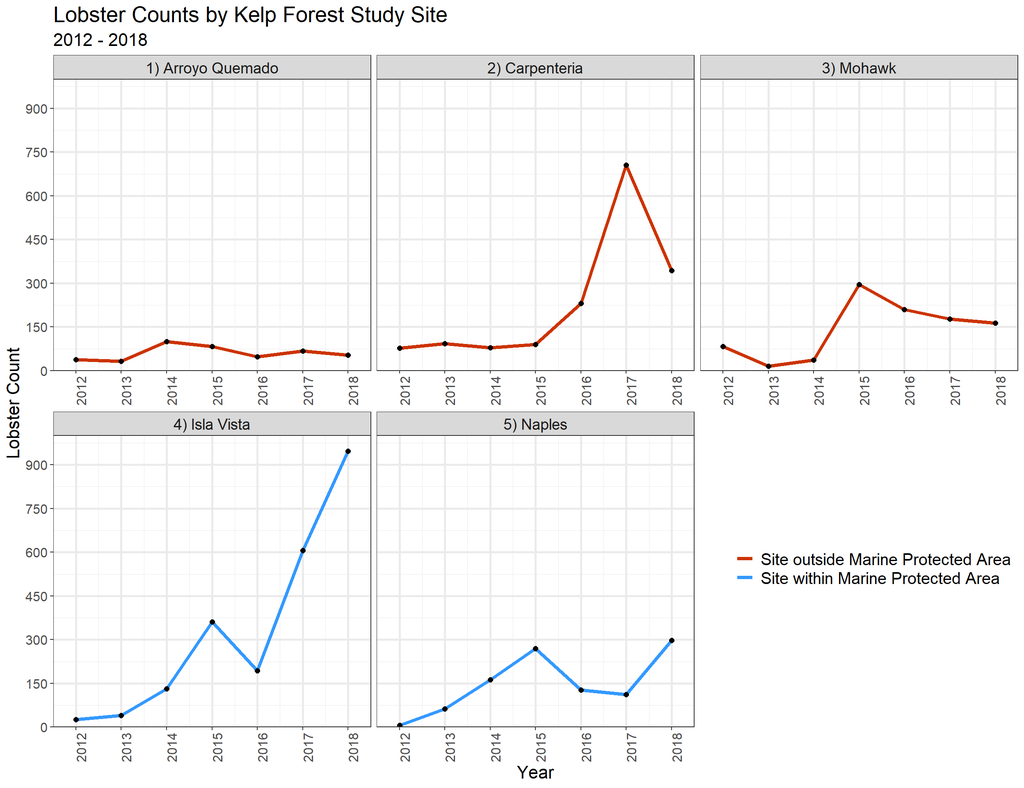

**Figure 3.** *Annual lobster counts for each of the five sampling locations from 2012-2018. Isla Vista and Naples sampling sites are within a Marine Protected Area (MPA). Arroyo, Carpenteria, and Mohawk sampling sites are not within an MPA. Data: SBC LTER.*

Some interesting trends are immediately noticeable. Lobster abundance increased by a large magnitude between 2016-2017 in both the Carpenteria and Isla Vista sites. However, while lobster abundance continued to quickly rise in Isla Vista from 2017-2018, there was a sharp decline in lobsters at the Carpenteria site during the same period. All sites saw significant declines in lobster counts between 2015-2016, with the exception of the Carpenteria site where lobster abundance began a period of growth. Between 2014-2015 all sites saw an increase in lobster counts with the exception of Arroyo Quemado. This site saw relatively stable annual lobster abundance during the 2012-2018 period.

One might reasonably assume that lobster counts would be consistently higher in all sites that are within a Marine Protected Area (MPA) as fishing pressure is reduced within their boundaries. While lobster abundance in the Isla Vista site looks more like what we would expect to see in these locations, data collected from the Naples site conveys that this is not always true. Despite being within an MPA, in 2018 the Carpenteria site (outside MPA) had a larger lobster count sample than the Naples site. Looking at the data, we cannot determine if MPA status in isolation has a direct effect on lobster abundance. It appears that other factors, such as ocean conditions, geographical location on the coast, and level of fishing pressure may also play a large role in lobster count differences between the five sites.

#### 2. Lobster size distrubutions in 2012 & 2018

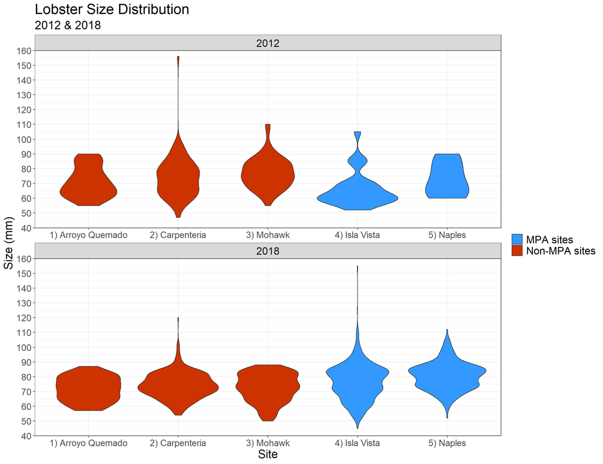

**Figure 4.** *Lobster size distributions across five sites in Santa Barbara county in 2012 and 2018. Data: SBC LTER.*

Sites within MPAs saw a recovery in large lobster populations from 2012 to 2018. Sites that do not have MPAs saw a reduction in large lobster populations over the same time period. Very small lobsters have also grown in number where MPAs exist (Isla Visa and Naples). These populations have been reduced in all non-MPA sites except for Mohawk, where small lobster populations have increased from 2012 to 2018.

Small and large lobster populations found at sites within MPAs have grown in extent and population density. The opposite is nearly true with sites found outside of MPAs, except for Mohawk. The Mohawk site is an anomoly because lobster populations have grown in number and extent despite the fact that the site is not protected. This may be the case due to a particular geographic characteristic of the Mohawk site that shelters small lobsters better than other non-MPA sites.

#### 3. Do Marine Protected Areas have a statistically significant affect on lobster size?

One interesting factor we would like to determine between the five sampling sites is if Marine Protected Areas (MPA) have an affect on average lobster size. Two of the five sampling sites (Isla Vista & Naples) are within the boundaries of an MPA while the other three (Arroyo, Carpenteria, Mohawk) are not. These sites were grouped together and sample statistics were calculated for the year 2012 and 2018 (Figure 5).

Figure 5. Lobster size sample statistics grouped in MPA and non-MPA sites in 2012 and 2018.

| Year | MPA or non-MPA Sites | Mean lobster size (mm) | Standard Deviation (mm) | Sample Size (# of lobsters) |
| --- | --- | --- | --- | --- |
| 2012 | MPA | 67.38 | 12.15 | 32 |
| 2012 | non-MPA | 74.92 | 12.41 | 199 |
| 2018 | MPA | 77.57 | 11.70 | 1244 |
| 2018 | non-MPA | 73.62 | 10.09 | 561 |

In 2012, there were very few lobsters observed within MPA sites (n = 32) while in 2018 lobster observations increased nearly 38 times that amount. Lobster counts within non-MPA sites nearly tripled between 2012 and 2018 measurements. In 2012, lobsters sampled in non-MPA sites were on average 7.54 mm larger then lobsters from MPA sites. However, in 2018 lobsters sampled in non-MPA sites were on average 3.95 mm smaller then lobsters from MPA sites. Comparing average lobster size in 2018 compared to 2012 within MPA sites we see an increase in average lobster size by about 10.19 mm, or about a 15% increase. Comparing average lobster size in 2018 compared to 2012 within non-MPA sites we see a decrease in average lobster size by about 1.3 mm, or about a 1.7% decrease.

> $H_0$: Mean size is the same between lobsters in Marine Protected Areas and those from outside of Marine Protected Areas.

> $H_A$: Mean size is different between lobsters in Marine Protected Areas and those from outside of Marine Protected Areas.

##### **RESULTS:**

##### *2012 MPA vs. Non-MPA Sites:*

Mean lobster size in MPA sites sampled in 2012 (67.38 $\pm$ 12.15, n = 32) differed significantly from mean lobster size in non-MPA sites in 2012 (74.92 $\pm$ 12.41, n = 199) by a two-sided, two sample t-test (t(42.09) = -3.25, *p* = 0.002). With a moderate effect size (Cohen’s *d* = 0.61), the magnitude of the increase in mean lobster size within non-MPA sites compared to MPA sites in 2012 is noticeable upon careful review.

##### *2012 vs. 2018 MPA Sites:*

Mean lobster size differed significantly between MPA sites in 2012 and 2018 (t(32.5) = -4.69, *p* < 0.001). The magnitude of the difference in lobster size in 2018 compared to 2012 was large (Cohen’s *d* = 0.87).

##### *2012 vs. 2018 Non-MPA Sites:*

There is not enough evidence to conclude that mean lobster size was significantly different within non-MPA sites in 2012 vs. 2018 (t(296.01) = 1.33, *p* = 0.183) In addition, the effect size was negligible (Cohen’s *d* = 0.12).

### **Summary**

- Lobster abundance does not seem to be affected by the MPA status of a site. Other factors such as ocean conditions, site-specfic habitat, fishing pressure, etc. are likely to contribute more heavily.
- Sites within MPAs experience growth in large and small lobster populations. Sites outside of MPAs experience decreases over the same populations respectively.
- The population density of large lobsters increases from 2012 to 2018 in sites within MPAs. The same populations decrease in sites that do not fall within an MPA over this same period of time.
- Mean lobster size differs significantly between MPA sites and non-MPA sites. This difference was nearly twice as great in 2012 as it was in 2018.

### **References**

**Reed D. 2019.** SBC LTER: Reef: Abundance, size and fishing effort for California Spiny Lobster (Panulirus interruptus), ongoing since 2012. Environmental Data Initiative. https://doi.org/10.6073/pasta/a593a675d644fdefb736750b291579a0. Dataset accessed 11/13/2019.